# MITx-15.071x-U1-Loading_Data_Files

Rahul Yadav

April 10, 2016

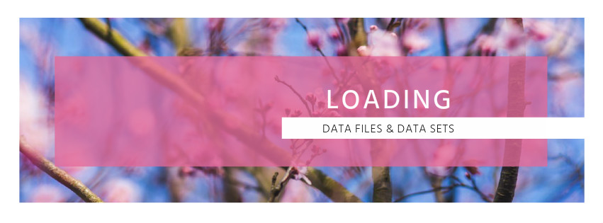

## ABOUT:

Often as a Data Analyst, one has to work with *external data files and data sets*. Some common data file formats are as follows:

- **.csv** or *Commma Seperated Values ~ variables*.
- **.xml** or *Extensible markup language* files.
- **.json** or *Javascript object notation*.
- **.txt** or *simple text*.

As for today, we are going to work with only **.csv** files.

## Objective:

- Loading a .csv file from an external location using command line in R console.
  - Prelimanary:
    - Viewing current working directory.
    - Setting working directory to data file ~ data set path.

## Implementation

> **Viewing Current Working directory**, *command* : **getwd()**

```r
getwd()
```

```
## [1] "C:/Users/pySag/Desktop/Major_Project_Summer_2016/Sectorwise_Data_Sets/Health & Family welfare"
```

```r
# Lest's view the files which we want to import. For this session we would like to import "WHO.csv"
list.files()
```

```
## [1] "govthospitalbeds2013jan.csv" "WHO.csv"
```

```r
# Also a good idea will be to save our workspace for frequent usage of our data files.
save.image()
```

**NOTE** : Everytime you want to work with a data file, you have to manually set the directory again each time. This is the only issue with the R markdown, but until somebody finds a way to resolve this issue we have to manage things on our own. **Update!** : Using **Knitr::opts_knit$set(root.dir = “insert working directory path”)**. It will set the working directory for all code chunks!

[output not shown]

> **Viewing the Summary of our data file**

A good way to look at our data without getting ourselves into it’s complexity is by summarizing our data as a summary statistics.

We can do this by two functions offered by R. Following are the two functions that we are going to use:

1. **summary()**
2. **structure**

```r
summary(WHO)
```

```
##                 Country                      Region     Population
##  Afghanistan        :  1   Africa               :46   Min.   :      1
##  Albania            :  1   Americas             :35   1st Qu.:   1696
##  Algeria            :  1   Eastern Mediterranean:22   Median :   7790
##  Andorra            :  1   Europe               :53   Mean   :  36360
##  Angola             :  1   South-East Asia      :11   3rd Qu.:  24535
##  Antigua and Barbuda:  1   Western Pacific      :27   Max.   :1390000
##  (Other)            :188
##     Under15          Over60      FertilityRate   LifeExpectancy
##  Min.   :13.12   Min.   : 0.81   Min.   :1.260   Min.   :47.00
##  1st Qu.:18.72   1st Qu.: 5.20   1st Qu.:1.835   1st Qu.:64.00
##  Median :28.65   Median : 8.53   Median :2.400   Median :72.50
##  Mean   :28.73   Mean   :11.16   Mean   :2.941   Mean   :70.01
##  3rd Qu.:37.75   3rd Qu.:16.69   3rd Qu.:3.905   3rd Qu.:76.00
##  Max.   :49.99   Max.   :31.92   Max.   :7.580   Max.   :83.00
##                                  NA's   :11
##  ChildMortality    CellularSubscribers  LiteracyRate        GNI
##  Min.   :  2.200   Min.   :  2.57      Min.   :31.10   Min.   :  340
##  1st Qu.:  8.425   1st Qu.: 63.57      1st Qu.:71.60   1st Qu.: 2335
##  Median : 18.600   Median : 97.75      Median :91.80   Median : 7870
##  Mean   : 36.149   Mean   : 93.64      Mean   :83.71   Mean   :13321
##  3rd Qu.: 55.975   3rd Qu.:120.81      3rd Qu.:97.85   3rd Qu.:17558
##  Max.   :181.600   Max.   :196.41      Max.   :99.80   Max.   :86440
##                    NA's   :10          NA's   :91      NA's   :32
##  PrimarySchoolEnrollmentMale PrimarySchoolEnrollmentFemale
##  Min.   : 37.20              Min.   : 32.50
##  1st Qu.: 87.70              1st Qu.: 87.30
##  Median : 94.70              Median : 95.10
##  Mean   : 90.85              Mean   : 89.63
##  3rd Qu.: 98.10              3rd Qu.: 97.90
##  Max.   :100.00              Max.   :100.00
##  NA's   :93                  NA's   :93
```

**Note**: While we can use structure(), using in R markdown document is not a good idea. Why? because it will return a table of all atrributes and will make things messy. Hence we refrain ourselves for using structure(). It is best utilized in Rstudio console only.

## Analysis:

> A **Factor** data type contains categorical data aswell as numerical data binded into single entity called *Factor*.

We also have some variables with missing values, such type of missing entitys are marked as **NA**. Missing values can generated error and don’t help in data analysis. Hence a good thing will be to replace these with normalized values of other similar variables.